# Assignment 1.3 : R Refresher

Gourav Verma

Sept 05 2020

#### **Que 1: Using the Bureau of Labor Statistics data, choose a dataset that interest you. Then generate summary statistics for 2 variables, plot some of the features (e.g., histograms, box plots, density plots, etc.) of several variables, and save the data locally as CSV files.**

##### ==> Read the CSV File from Bureau of Labor Statistics

```r
OES <- read.csv("OES_data_M_2019.csv")
```

##### ==> summary statistics for 2 variables

##### **tot_emp:** Estimated total employment rounded to the nearest 10 (excludes self-employed).

```r
summary(as.numeric(OES$tot_emp))
```

```
##    Min. 1st Qu.  Median    Mean 3rd Qu.    Max.
##       1    1951    5644    5473    8702   12052
```

##### **a_mean:** Mean annual wage

```r
summary(as.numeric(OES$a_mean))
```

```
##    Min. 1st Qu.  Median    Mean 3rd Qu.    Max.
##       1   10356   11550   11117   13268   17232
```

##### ==> plot some of the features

##### **Histogram of area_type**. Area type: 1= U.S.; 2= State; 3= U.S. Territory; 4= Metropolitan Statistical Area (MSA) or New England City and Town Area (NECTA); 6= Nonmetropolitan Area

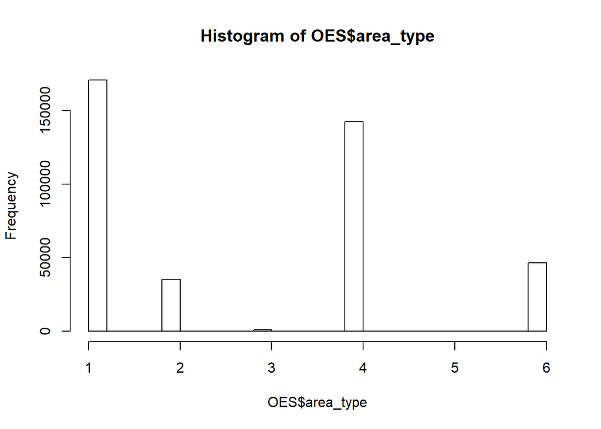

```r
hist(OES$area_type)
```

##### **Box plot of annual mean wage**

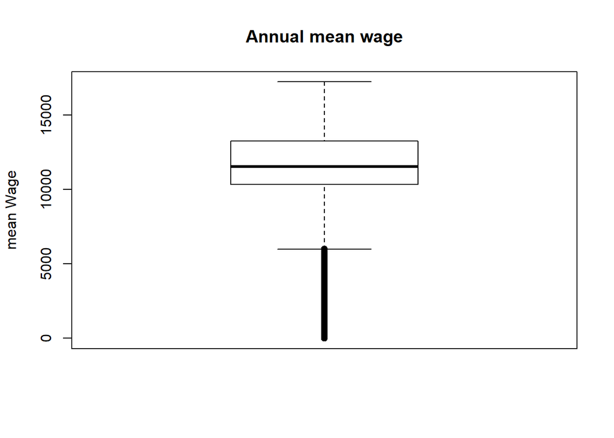

```r
boxplot(as.numeric(OES$a_mean), main='Annual mean wage', ylab="mean Wage")
```

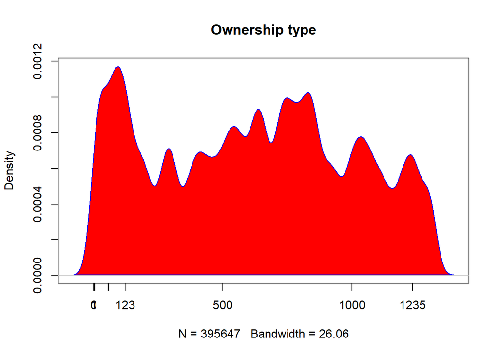

```r
d <- density(as.numeric(OES$occ_code))
plot(d, main="Ownership type")
polygon(d, col="red", border="blue")
axis(side=1,at=OES$own_code)
```

##### **Density plot**

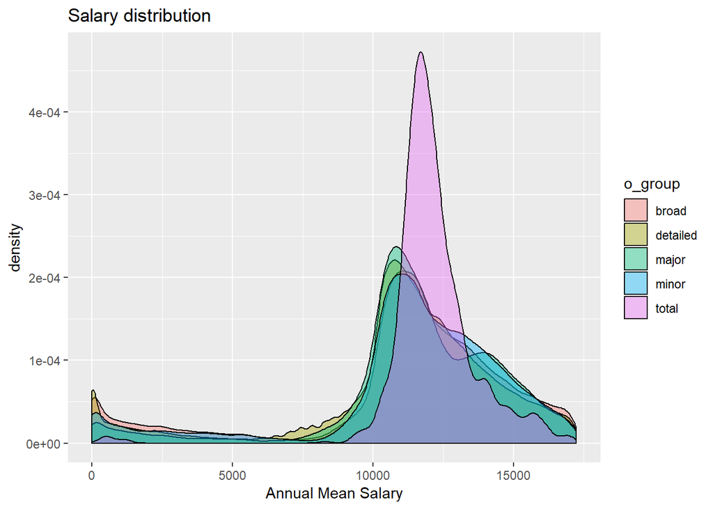

```r
ggplot(OES,
       aes(x = as.numeric(OES$a_mean),
           fill = o_group)) +
    geom_density(alpha = 0.4) +
    labs(title = 'Salary distribution') +
    xlab("Annual Mean Salary")
```

##### **Density plot**

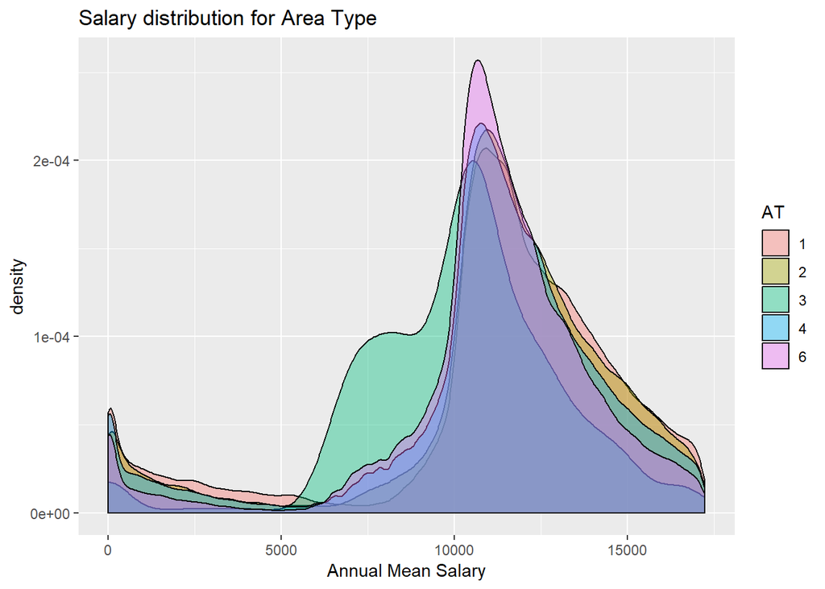

```r
AT <- as.factor(OES$area_type)
ggplot(OES,
       aes(x = as.numeric(OES$a_mean),
           fill = AT)) +
    geom_density(alpha = 0.4) +
    labs(title = 'Salary distribution for Area Type') +
    xlab("Annual Mean Salary")
```

##### **Write into CSV file**

```r
write.csv(OES, "OES_new.csv")
```

#### **Que 2:** Explore Some Bivariate Relations

##### **Scatter plot between annual mean wage and PRSE error**

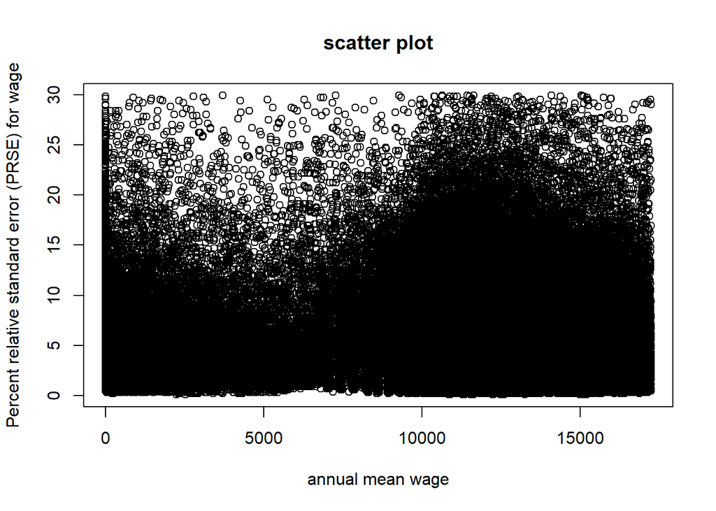

```r
plot(as.numeric(OES$a_mean), as.numeric(as.character(OES$mean_prse)), main="scatter plot",
     xlab="annual mean wage", ylab="Percent relative standard error (PRSE) for wage")
```

#### **Que 3:** Organize a Data Report

##### The default CSV read takes the datatypes automatically. For furhter analysis datatype conversion is required.

##### a. **Area Type** is a categorical field with 5 distinct values.

- 1 = U.S.
- 2 = State
- 3 = U.S. Teritory
- 4 = Metropolitan Statistical Area (MSA) or New England City and Town Area (NECTA)
- 6 = Nonmetropolitan Area

##### b. **OCC code and Title** are categorical fields which contains code and title of occupation.

##### c. **h_mean and a_mean** are float variables which represents hourly and Annual mean wage respectively for perticular job code in the area type.

##### d. **Ownership code** is a categorical variable for type of ownership of the occupation title.

Ownership type: + 1= Federal Government; + 2= State Government; + 3= Local Government; + 123= Federal, State, and Local Government; + 235=Private, State, and Local Government; + 35 = Private and Local Government; + 5= Private; + 57=Private, Local Government Gambling Establishments (Sector 71), and Local Government Casino Hotels (Sector 72); + 58= Private plus State and Local Government Hospitals; + 59= Private and Postal Service; + 1235= Federal, State, and Local Government and Private Sector

##### Below is the summary of the datatet

```r
str(OES)
```

```
## 'data.frame':    395647 obs. of  30 variables:
##  $ area          : int  99 99 99 99 99 99 99 99 99 99 ...
##  $ area_title    : Factor w/ 585 levels "Abilene, TX",..: 530 530 530 530 530 530 530 530 530 530 ...
##  $ area_type     : int  1 1 1 1 1 1 1 1 1 1 ...
##  $ naics         : Factor w/ 420 levels "000000","000001",..: 1 1 1 1 1 1 1 1 1 1 ...
##  $ naics_title   : Factor w/ 393 levels "Accommodation",..: 75 75 75 75 75 75 75 75 75 75 ...
##  $ i_group       : Factor w/ 9 levels "3-digit","3-digit, ownership",..: 7 7 7 7 7 7 7 7 7 7 ...
##  $ own_code      : int  1235 1235 1235 1235 1235 1235 1235 1235 1235 1235 ...
##  $ occ_code      : Factor w/ 1316 levels "00-0000","11-0000",..: 2 66 115 145 205 280 306 321 415 472 ...
##  $ occ_title     : Factor w/ 1064 levels "Accountants and Auditors",..: 585 113 178 52 555 169 541 294 63 462 ...
##  $ o_group       : Factor w/ 5 levels "broad","detailed",..: 3 3 3 3 3 3 3 3 3 3 ...
##  $ tot_emp       : Factor w/ 12052 levels "**","1,000","1,003,040",..: 10909 10923 7161 3617 153 3552 91 11001 3496 10978 ...
##  $ emp_prse      : Factor w/ 501 levels "**","0.0","0.1",..: 4 4 6 7 9 6 7 6 9 5 ...
##  $ jobs_1000_orig: Factor w/ 26893 levels "","**","0.002",..: 1 1 1 1 1 1 1 1 1 1 ...
##  $ loc_quotient  : num  NA NA NA NA NA NA NA NA NA NA ...
```

[output cut: 16 more lines]